# Reproducible Research: Peer Assessment 1

Robert Bril

## Introduction

It is now possible to collect a large amount of data about personal movement using activity monitoring devices such as a [Fitbit](http://www.fitbit.com), [Nike Fuelband](http://www.nike.com/us/en_us/c/nikeplus-fuelband), or [Jawbone Up](https://jawbone.com/up). These type of devices are part of the “quantified self” movement – a group of enthusiasts who take measurements about themselves regularly to improve their health, to find patterns in their behavior, or because they are tech geeks. But these data remain under-utilized both because the raw data are hard to obtain and there is a lack of statistical methods and software for processing and interpreting the data.

This assignment makes use of data from a personal activity monitoring device. This device collects data at 5 minute intervals through out the day. The data consists of two months of data from an anonymous individual collected during the months of October and November, 2012 and include the number of steps taken in 5 minute intervals each day.

## Data

The data for this assignment can be downloaded from the course web site:

- Dataset: [Activity monitoring data](https://d396qusza40orc.cloudfront.net/repdata%2Fdata%2Factivity.zip) [52K]

The variables included in this dataset are:

- **steps**: Number of steps taking in a 5-minute interval (missing values are coded as `NA`)
- **date**: The date on which the measurement was taken in YYYY-MM-DD format
- **interval**: Identifier for the 5-minute interval in which measurement was taken

The dataset is stored in a comma-separated-value (CSV) file and there are a total of 17,568 observations in this dataset.

## Load Libraries

```r
library(lubridate)
library(ggplot2)
library(knitr)
library(stringr)
library(scales)
knitr::opts_chunk$set(echo = TRUE)
```

## Loading and preprocessing the data

The code assumes you have set the working directory. If required it will create a download directory and download the dataset and unzip it. The data are loaded into a main activity dataset (“ACT”) with appropriate formatting.

Note the presence of NAs in the dataset.

```r
if(!file.exists("./data")){
        dir.create("./data")}

if(!file.exists("./data/Act.zip")){
        fileUrl <- "https://d396qusza40orc.cloudfront.net/repdata%2Fdata%2Factivity.zip"
        download.file(fileUrl,destfile = "./data/Act.zip")
        unzip("./data/Act.zip",exdir = "./data")
        file.rename("./data/Activity.csv","./data/Act.csv")
        file.remove("./data/Act.zip")
        rm(fileUrl)
        }

if(!exists("ACT")){
        ACT <- read.csv("../data/Act.csv",na.strings = "NA",stringsAsFactors = FALSE)
        ACT$date <- as.Date(ACT$date,"%Y-%m-%d")
        ACT$day_type <- weekdays(ACT$date) =="Sunday" | weekdays(ACT$date) =="Saturday"
        ACT$day_type <- factor(ACT$day_type, levels=c(FALSE,TRUE),labels=c("weekday","weekend"))
        ACT$interval <-str_sub(paste(rep("000",nrow(ACT)),ACT$interval,sep=""),start=-4)
}

head(ACT)
```

```
##   steps       date interval day_type
## 1    NA 2012-10-01     0000  weekday
## 2    NA 2012-10-01     0005  weekday
## 3    NA 2012-10-01     0010  weekday
## 4    NA 2012-10-01     0015  weekday
## 5    NA 2012-10-01     0020  weekday
## 6    NA 2012-10-01     0025  weekday
```

## What is mean total number of steps taken per day?

For this stage the NAs observed earlier were ignored. Some basic statistics for the daily totals are computed.

```r
Daily_Totals <- tapply(ACT$steps,ACT$date,sum,na.rm=TRUE)
mnDT <- mean(Daily_Totals)
mdDT <- median(Daily_Totals)
print(paste("Mean Total Steps/Day:",mnDT))
```

```
## [1] "Mean Total Steps/Day: 9354.22950819672"
```

```r
print(paste("Median Total Steps/Day:",mdDT))
```

```
## [1] "Median Total Steps/Day: 10395"
```

It is observed that the mean is significantly less than the median which implies a skewed distribution. A histogram was plotted to check the distribution of daily totals.

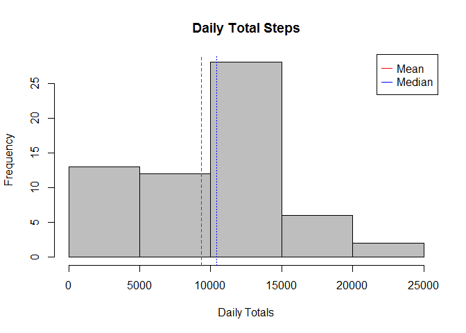

```r
hist(Daily_Totals, col = "gray",main = "Daily Total Steps", xlab="Daily Totals")
abline(v=mnDT, col="red",lty=2)
abline(v=mdDT, col="blue",lty=3)
legend("topright",legend=c("Mean","Median"),pch=151,col=c("red","blue"))
```

## What is the average daily activity pattern?

In this section the average activity for each five minute time interval over every date was calculated.

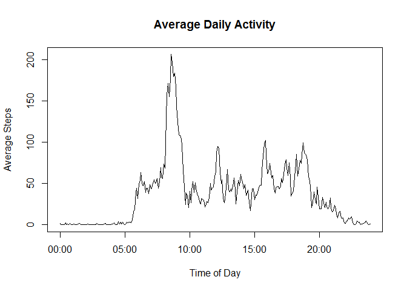

```r
Daily_activity <- aggregate(steps~interval,ACT,FUN=mean,na.rm=TRUE)
Daily_activity$Time <- as.POSIXct(strptime(Daily_activity$interval,"%H%M",tz="UTC"))

plot(x=Daily_activity$Time,y=Daily_activity$steps,
     main = "Average Daily Activity",
     ylab="Average Steps",
     xlab = "Time of Day",
     type="l")
```

It was observed that the maximum activity on average was at 08:35am

```r
print(paste("Max Average Steps taken at:",(Daily_activity[which.max(Daily_activity$steps),]$interval)))
```

```
## [1] "Max Average Steps taken at: 0835"
```

## Imputing missing values

In this section the missing values were imputed using a basic model.

First, the extent of the problem was measured. A large number of NAs were found (13%) but the heatmap shows that all the NAs are isolated to 8 missing days.

```r
print(paste("Total Number of NAs:",sum(is.na(ACT$steps))))
```

```
## [1] "Total Number of NAs: 2304"
```

```r
print(paste("Proportion of NAs:",100*mean(is.na(ACT$steps)),"%"))
```

```
## [1] "Proportion of NAs: 13.1147540983607 %"
```

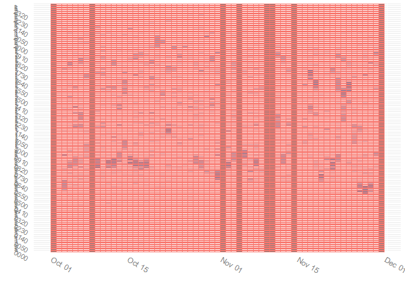

```r
# Heat map to find NA distribution
base_size <-10
xbase_size <- 10
ybase_size <- c(10,0,0,0,0,0,0,0,0,0)

(p <- ggplot(ACT, aes(date, interval))
+ geom_tile(aes(fill = steps, colour = "white"))
+ scale_fill_gradient(low = "white", high = "steelblue")
+ theme_grey(base_size = base_size)  + labs(x = "", y = "")
+ theme(legend.position = "none",
        axis.ticks = element_blank(),
        axis.text.x = element_text(size = xbase_size * 1, angle = 330,
                                   hjust = 0, colour = "grey50"),
        axis.text.y = element_text(size = ybase_size * 0.8, angle = 330,
                                   hjust = 0, colour = "grey50"))
        )
```

The missing data form the columns (date) of the heatmap above. This suggests that the missing values can be replaced with values imputed by the rows (interval) of the heatmap. Since the interval means were calculated in the previous step, these were used here:

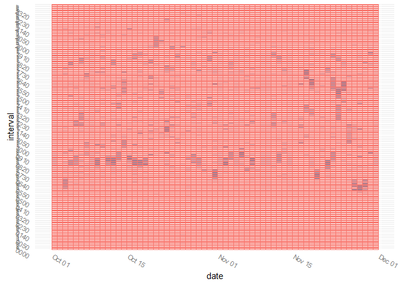

```r
ACT2 <-ACT

for (i in 1:nrow(ACT2)){
        if (is.na(ACT2[i,1])) ACT2[i,1]<-Daily_activity[which(ACT2[i,3] == Daily_activity[,1]),2]
}

# Heatmap Post-Imputation

(p <- ggplot(ACT2, aes(date, interval))
+ geom_tile(aes(fill = steps, colour = "white"))
+ scale_fill_gradient(low = "white", high = "steelblue")
# + theme_grey(base_size = base_size)  + labs(x = "", y = "")
+ theme(legend.position = "none",
        axis.ticks = element_blank(),
        axis.text.x = element_text(size = xbase_size * 0.8, angle = 330,
                                   hjust = 0, colour = "grey50"),
        axis.text.y = element_text(size = ybase_size * 0.8, angle = 330,
                                   hjust = 0, colour = "grey50"))
)
```

A histogram was plotted to visualize this hypothesis.

```r
Daily_Totals2 <- tapply(ACT2$steps,ACT2$date,sum,na.rm=TRUE)
mnDT2 <- mean(Daily_Totals2)
mdDT2 <- median(Daily_Totals2)
print(paste("Mean Total Steps/Day (after imputation):",mnDT2))
```

```
## [1] "Mean Total Steps/Day (after imputation): 10766.1886792453"
```

```r
print(paste("Median Total Steps/Day (after imputation):",mdDT2))
```

```
## [1] "Median Total Steps/Day (after imputation): 10766.1886792453"
```

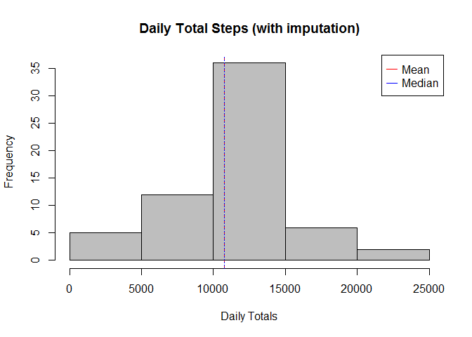

```r
hist(Daily_Totals2, col = "gray",main = "Daily Total Steps (with imputation)", xlab="Daily Totals")
abline(v=mnDT2, col="red",lty=2)
abline(v=mdDT2, col="blue",lty=3)
legend("topright",legend=c("Mean","Median"),pch=151,col=c("red","blue"))
```

Note that much of the first bin of the histogram has been moved to the mean as expected. This increases the mean but only has a minor effect on the median. The median interval values might have been a more stable value on which to base the imputation.

## Are there differences in activity patterns between weekdays and weekends?

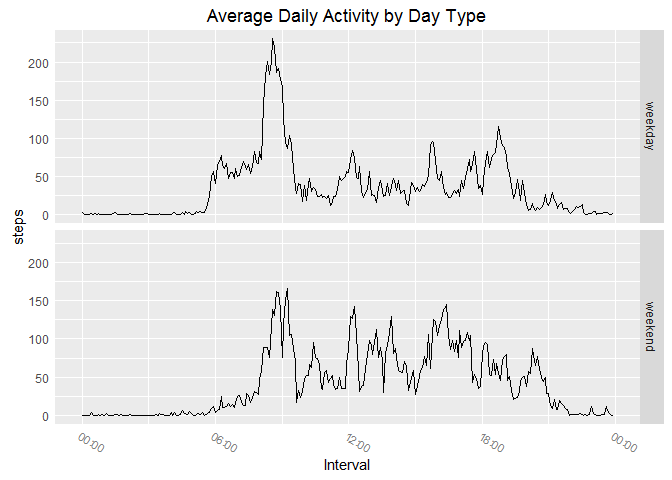

```r
Daily_activity <- aggregate(steps~interval,ACT,FUN=mean,na.rm=TRUE)
Wkdy_activity <- aggregate(steps~interval+day_type,ACT2,FUN=mean,na.rm=TRUE)
Wkdy_activity$Time <- as.POSIXct(strptime(Daily_activity$interval,"%H%M",tz="UTC"))

base_size = 10

g <- ggplot(Wkdy_activity, aes(Time,steps))
( g + geom_line()+facet_grid(day_type~.)
+theme(legend.position = "none", axis.ticks = element_blank(),
                                axis.text.x = element_text(size = base_size * 0.8,
                                                           angle = 330,
                                 hjust = 0, colour = "grey50"))
+ labs(title = "Average Daily Activity by Day Type")
+ scale_x_datetime("Interval",labels = date_format("%H:%M"))   )
```

It’s clearly noticeable that activity starts and finishes later on weekends. The overall activity level seems to be higher, but the maximum is lower.